### The Effect of Transmission Type on Fuel Efficiency

#### Executive Summary

This analysis addresses whether an automatic or manual transmission is better for MPG. It attempts to quantify the MPG difference between automatic and manual transmissions.

Among vehicles in the sample data, this analysis finds:

- Automatic transmissions were more fuel efficient manual transmissions
- Without controlling for any other variables, Automatic transmissions add 7.3 MPG over Manual transmissions
- The selected model controls for number of carburateurs, V-shape engine, and country of manufacture; given these controls Automatic transmissions add an extra 5.8 MPG, with a 95% confidence interval of 2.4 to 9.2 MPG

#### Data Transformations

The sole transformation was to add a variable, country, which grouped cars by country of manufacture. The models were grouped as:

- Sweden: Volvo 142E
- England: Lotus Europa
- Italy: Fiat 128, Fiat X1-9, Ferrari Dino, Maserati Bora
- Japan: Mazda RX4,Mazda RX4 Wag,Datsun 710,Honda Civic, Toyota Corolla,Toyota Corona
- Germany: Merc 240D, Merc 230, Merc 280, Merc 280C, Merc 450SE, Merc 450SL, Merc 450SLC, Porsche 914-2
- USA: Hornet 4 Drive, Hornet Sportabout, Valiant, Duster 360, Cadillac Fleetwood, Lincoln Continental, Chrysler Imperial, Dodge Challenger, AMC Javelin, Camaro Z28, Pontiac Firebird, Ford Pantera L

#### Discussion

The variable weight (wt) is a significant confounder. Whether the am variable was significant was largely influenced by whether wt was in the model. In models including the wt variable, the am variable tended not to be significant.

#### Figure 1. Data variables in mtcars data

```
##  [1] "mpg"  "cyl"  "disp" "hp"   "drat" "wt"   "qsec" "vs"   "am"   "gear"
## [11] "carb"
```

#### Figure 2. Miles per Gallon vs. Transmission Type

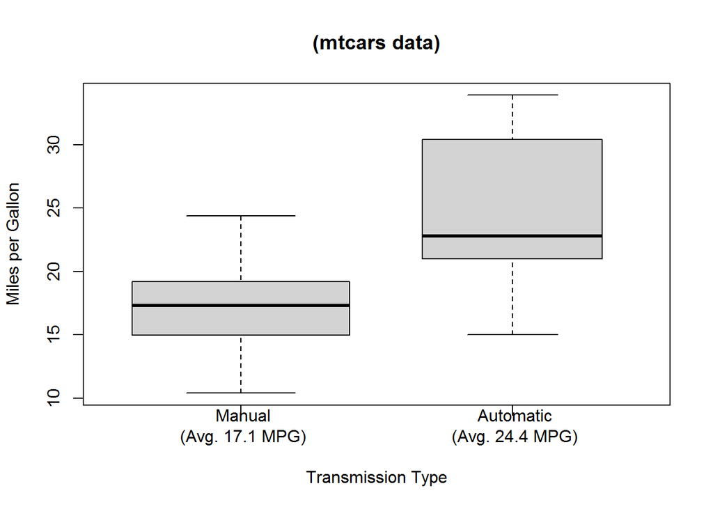

#### Figure 3. Correlation Matrix

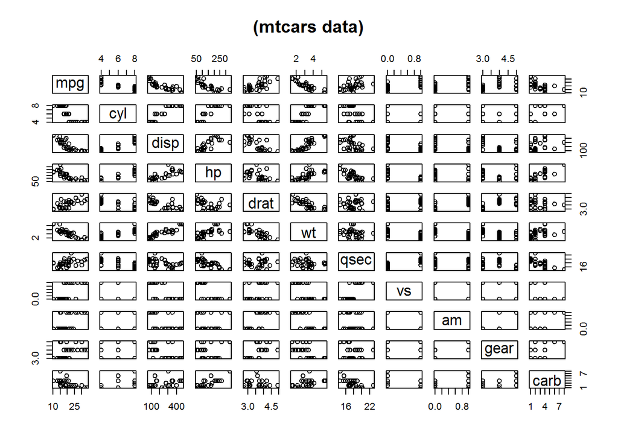

#### Figure 4. Multiple Regression using all variables: Summary

```
##
## Call:
## lm(formula = mpg ~ ., data = mtcars)
##
## Residuals:
##    Min     1Q Median     3Q    Max
##  -3.45  -1.60  -0.12   1.22   4.63
##
## Coefficients:
##             Estimate Std. Error t value Pr(>|t|)
## (Intercept)  12.3034    18.7179    0.66    0.518
## cyl          -0.1114     1.0450   -0.11    0.916
## disp          0.0133     0.0179    0.75    0.463
## hp           -0.0215     0.0218   -0.99    0.335
## drat          0.7871     1.6354    0.48    0.635
## wt           -3.7153     1.8944   -1.96    0.063 .
## qsec          0.8210     0.7308    1.12    0.274
## vs            0.3178     2.1045    0.15    0.881
## am            2.5202     2.0567    1.23    0.234
## gear          0.6554     1.4933    0.44    0.665
## carb         -0.1994     0.8288   -0.24    0.812
## ---
## Signif. codes:  0 '***' 0.001 '**' 0.01 '*' 0.05 '.' 0.1 ' ' 1
##
## Residual standard error: 2.65 on 21 degrees of freedom
## Multiple R-squared:  0.869,  Adjusted R-squared:  0.807
## F-statistic: 13.9 on 10 and 21 DF,  p-value: 3.79e-07
```

#### Figure 5. Fit Analysis, Multiple Regression using All Variables

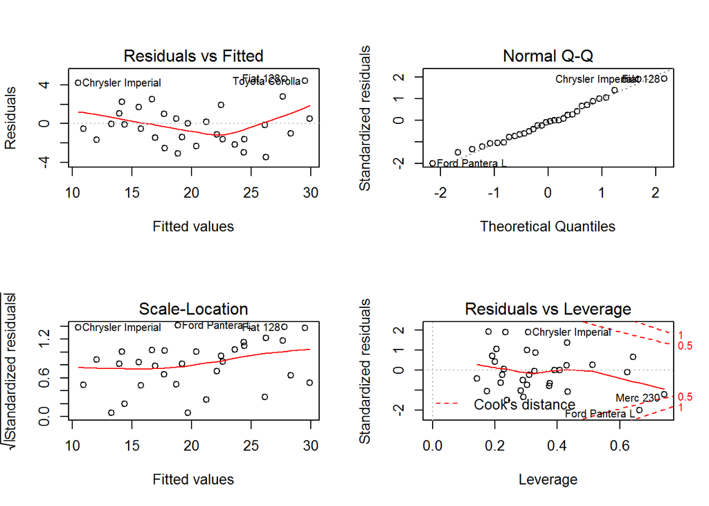

#### Figure 6. Variance Inflation Factors, All Variables

```
##    cyl   disp     hp   drat     wt   qsec     vs     am   gear   carb
## 15.374 21.620  9.832  3.375 15.165  7.528  4.966  4.648  5.357  7.909
```

#### Figure 7. Multiple Regression using country and other variables: Summary

[output not shown]

```
##
## Call:
## lm(formula = mpg ~ vs + am + carb + country, data = data)
##
## Residuals:
##    Min     1Q Median     3Q    Max
## -6.262 -1.268  0.015  1.195  4.838
##
## Coefficients:
##                Estimate Std. Error t value Pr(>|t|)
## (Intercept)       25.21       3.80    6.63  9.2e-07 ***
## vs                 2.85       1.38    2.06  0.05092 .
## am                 5.84       1.65    3.54  0.00174 **
## carb              -1.75       0.39   -4.49  0.00017 ***
## countryGermany    -2.45       3.21   -0.76  0.45234
## countryItaly      -1.88       2.96   -0.64  0.53117
## countryJapan      -3.09       2.84   -1.09  0.28850
## countrySweden     -9.00       3.65   -2.47  0.02146 *
## countryUSA        -5.64       3.35   -1.68  0.10603
## ---
## Signif. codes:  0 '***' 0.001 '**' 0.01 '*' 0.05 '.' 0.1 ' ' 1
##
## Residual standard error: 2.58 on 23 degrees of freedom
## Multiple R-squared:  0.864,  Adjusted R-squared:  0.817
## F-statistic: 18.3 on 8 and 23 DF,  p-value: 2.92e-08
```